# Визуализация в анализе данных

Курс "Модели и методы интеллектуального анализа данных"

## Применение визуализации

1. Предварительный анализ данных, поиск закономерностей
2. Визуализация процесса исследования данных
3. Представление результатов

## Стандартные пакеты python для визуализации

| matplotlib | https://matplotlib.org/ |
| --- | --- |
| seaborn | https://seaborn.pydata.org/ |
| ggplot | https://ggplot2.tidyverse.org/ |

## matplotlib

#### Импортировать библиотеку matplotlib и посмотреть текущую используемую версию.

```python
import matplotlib
from matplotlib import pyplot as plt
```

```python
m=!pip freeze
for elem in m:
    if elem.find("matplotlib")!=-1:
        print(elem)
print(matplotlib.__version__)
print(matplotlib.get_backend())
```

```
matplotlib==3.1.1
3.1.1
module://ipykernel.pylab.backend_inline
```

#### Нарисовать графики произвольных непрерывных функций разными цветами (зеленый, желтый, красный, синий, черный), разной плотности (5 разных значений), разными стилями (сплошная линия, пунктирная, «точка-тире»).

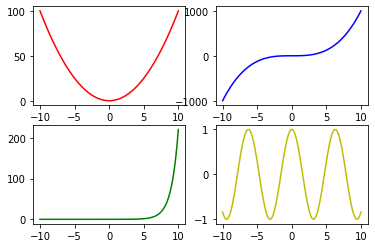

```python
import numpy as np
import math

x=np.linspace(-10,10,100)
fig,ax=plt.subplots(2,2)
ax[0][0].plot(x,[i**2 for i in x],color="r", label="square")
ax[0][1].plot(x,[i**3 for i in x],color="b", label="cube")
ax[1][0].plot(x,[math.exp(i)/100 for i in x],color="g",label="exp")
ax[1][1].plot(x,[math.cos(i) for i in x],color="y",label="cosine")
plt.show()
```

#### Нарисовать графики произвольных дискретных (численно заданных) функций, ис-пользуя разные цвета (зеленый, желтый, красный, синий, черный) и стили точек (квадрат, круг, треугольник, «алмаз»)

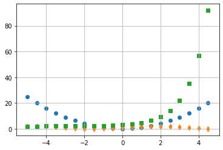

```python
x=np.arange(-5,5,0.5)
y1=[i**2 for i in x]
y2=[math.sin(i)+1 for i in x]
y3=[math.exp(i)+2 for i in x]
plt.scatter(x,y1,marker="o")
plt.scatter(x,y2,marker="d")
plt.scatter(x,y3,marker="s")
plt.grid(True)
```

## Модель рисунка matplotlib

[figure not shown]

Рисунок (Figure), Область рисования (Axes), Координатная ось (Axis), Элементы рисунка (Artists) - primitive, container

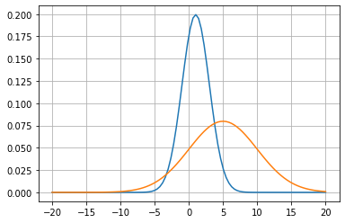

```python
from scipy.stats import norm

x=np.linspace(-20,20,100)
m, sigma=1,2
y1=[norm(m,sigma).pdf(i) for i in x]
plt.plot(x,y1)
m, sigma=5,5
y2=[norm(m,sigma).pdf(i) for i in x]
plt.plot(x,y2)
plt.grid(True)
```

#### Сохранить диаграмму в файл.

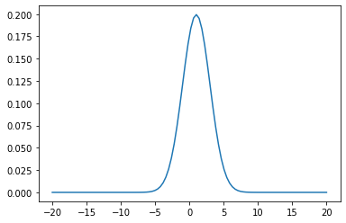

```python
x=np.linspace(-20,20,100)
m, sigma=1,2
y1=[norm(m,sigma).pdf(i) for i in x]
plt.plot(x,y1)
plt.savefig(r"fig.jpeg")
```

[figure not shown]

#### Нарисовать график функции y(x)=2*sin(3x-1)

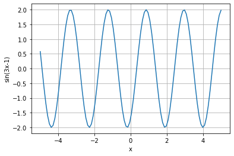

```python
x=np.linspace(-5,5,100)
y1=[2*math.sin(3*i-1) for i in x]
plt.grid(True)
plt.xlabel("x")
plt.ylabel("sin(3x-1)")
plt.plot(x,y1)
plt.show()
```

#### Нарисовать график функции в полярных координатах

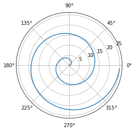

```python
phi=np.arange(0,4*np.pi,0.1)
rho=2*phi
plt.subplot(polar=True)
plt.plot(phi,rho)
plt.show()
```

#### Cоздать словарь с ключом–Фамилия и данными «Рост-Вес» отобразить на графике данные точками и у каждой точки подписать соответствующую фамилию.

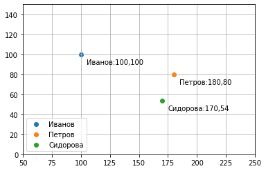

```python
persons=dict({"Иванов":[100,100],"Петров":[180,80],"Сидорова":[170,54]})
plt.xlim(50, 250)
plt.ylim(0, 150)
for surname in persons.keys():
    x,y=persons[surname][0],persons[surname][1]
    plt.scatter(x,y,label=surname)
    plt.text(x+5,y-10,surname+":"+str(x)+","+str(y))
    plt.legend(loc=3)
plt.grid(True)
```

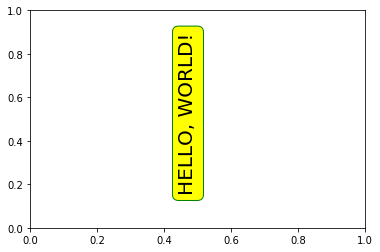

```python
plt.text(0.5, 0.9, "HELLO, WORLD!", size=20, rotation=90.,
         ha="right", va="top",
         bbox=dict(boxstyle="round", ec='green', color='yellow')
         )
```

#### Нарисовать олимпийские кольца разного цвета.

[figure not shown]

```python
circle1  = plt.Circle((20, 40), 10, color='r')
circle11 = plt.Circle((20, 40), 8, color='w')
circle2  = plt.Circle((50, 40), 10, color='b')
circle21 = plt.Circle((50, 40), 8, color='w')
circle3  = plt.Circle((80, 40), 10, color='g')
circle31 = plt.Circle((80, 40), 8, color='w')
circle4  = plt.Circle((35, 20), 10, color='y')
circle41 = plt.Circle((35, 20), 8, color='w')
circle5  = plt.Circle((65, 20), 10, color='m')
circle51 = plt.Circle((65, 20), 8, color='w')
fig, ax = plt.subplots()
ax.set_xlim(0, 100)
ax.set_ylim(0, 60)
for elem in [circle1, circle11, circle2, circle21, circle3, circle31, circle4, circle41, circle5, circle51]:
    ax.add_artist(elem)
ax.axis('off')
plt.show()
```

#### Построить гистограмму

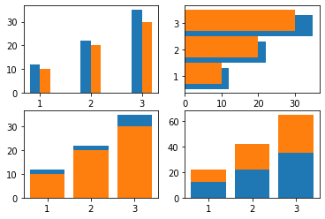

```python
fig, ax=plt.subplots(2,2)
x=[1,2,3]
y1=[10,20,30]
y2=[12,22,35]
ax[0][0].bar([i-0.1 for i in x],y2,width=0.2)
ax[0][0].bar([i+0.1 for i in x],y1,width=0.2)
ax[0][1].barh([i-0.1 for i in x],y2)
ax[0][1].barh([i+0.1 for i in x],y1)
ax[1][0].bar(x,y2)
ax[1][0].bar(x,y1)
ax[1][1].bar(x,y2)
ax[1][1].bar(x,y1,bottom=y2)
plt.show()
```

#### Нарисовать круговую диаграмму

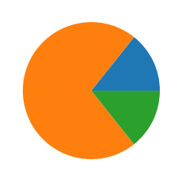

```python
plt.pie([10,50,10])
plt.show()
```

#### Нарисовать ящик с усами

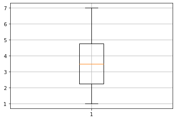

```
max:7, min:1, mean:3.6666666666666665, var:3.8888888888888893, std:1.9720265943665387
```

```python
y=[1,2,3,4,5,7]
plt.boxplot(y)
plt.grid(True)
plt.show()
print("max:{}, min:{}, mean:{}, var:{}, std:{}".format(max(y), min(y), np.mean(y), np.var(y), np.std(y)))
```

#### Написать функцию-«принтер» точек на плоскости, координаты которых определяются случайным образом. Тоже самое для координат, распределенных случайным образом по нормальному закону.

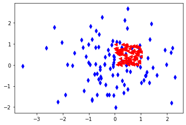

```python
def f_plotter(p_plt,num):
    x1=np.random.randn(num)
    y1=np.random.randn(num)
    p_plt.scatter(x1,y1,color="b", marker="d")
    x2=np.random.rand(num)
    y2=np.random.rand(num)
    p_plt.scatter(x2,y2,color="r", marker="<")
    p_plt.show()
f_plotter(plt,100)
```

#### Добавить несколько графиков на один рисунок

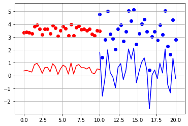

```python
x=np.linspace(0,10,30)
y1=np.random.rand(30)
y2=np.random.randn(30)
fig,ax=plt.subplots()
ax.plot(x,y1,color="red")
ax.plot(x+10,y2,color="blue")
ax.scatter(x,y1+3,color="red")
ax.scatter(x+10,y2+3,color="blue")
plt.grid(True)
plt.show()
```

#### Нарисовать 50 шаров разного цвета и размера

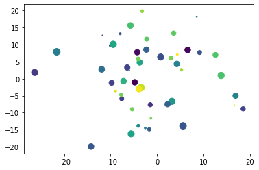

```python
v_colors=np.random.rand(50)
v_sizes=100*np.random.rand(50)
x=10*np.random.randn(50)
y=10*np.random.randn(50)
plt.scatter(x,y,marker="o",c=v_colors,s=v_sizes)
plt.show()
```

#### Визуализировать массив дискретных значений

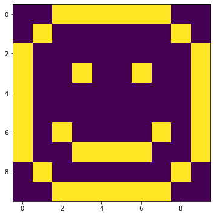

```python
smile = [[0, 0, 1, 1, 1, 1, 1, 1, 0, 0],
         [0, 1, 0, 0, 0, 0, 0, 0, 1, 0],
         [1, 0, 0, 0, 0, 0, 0, 0, 0, 1],
         [1, 0, 0, 1, 0, 0, 1, 0, 0, 1],
         [1, 0, 0, 0, 0, 0, 0, 0, 0, 1],
         [1, 0, 0, 0, 0, 0, 0, 0, 0, 1],
         [1, 0, 1, 0, 0, 0, 0, 1, 0, 1],
         [1, 0, 0, 1, 1, 1, 1, 0, 0, 1],
         [0, 1, 0, 0, 0, 0, 0, 0, 1, 0],
         [0, 0, 1, 1, 1, 1, 1, 1, 0, 0]]
fig, ax = plt.subplots()
ax.imshow(smile)
fig.set_figwidth(6)    #  ширина и
fig.set_figheight(6)    #  высота "Figure"
plt.show()
```

#### Нарисовать линии уровня поверхности

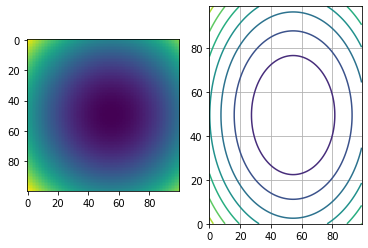

```python
x=np.linspace(-10,10,100)
y=np.linspace(-10,10,100)
z=[[(i-1)**2+j**2 for i in x] for j in y]
fig, ax = plt.subplots(1,2)
ax[0].imshow(z)
ax[1].contour(z)
plt.grid(True)
plt.show()
```

#### Интерактивный matplotlib

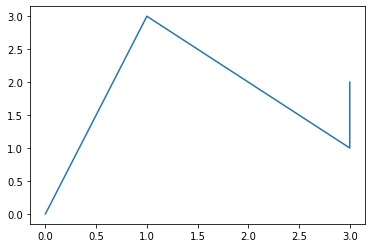

```python
#%matplotlib notebook
plt.plot([0, 1, 3, 3], [0, 3, 1, 2])
plt.show()
```

## Домашнее задание

1. Построить графики синуса, косинуса, логарифма, экспоненты
2. Нарисовать радугу, светофор, звездное небо, дом
3. Визуализировать входные данные задачи "Titanic disaster"